# Offensive Scouting Pipeline: Cross-Team Summary

One R pipeline, 4 offenses, same 56-column GamePBP schema. Every report below was produced by the same call:

```
build_scouting_report(file,
team)
```

.

## At a glance

| Team | Data | Plays | Pass % | Neutral pass % | EPA/play | Success | 3rd-down conv | Sack % | Under center % | Run/pass predictability |
| --- | --- | --- | --- | --- | --- | --- | --- | --- | --- | --- |
| New York Giants | Real | 515 | 58% | 51% | +0.00 | 44% | 42% | 9% | 37% | 58% -> 79% |
| Cleveland Browns | Real | 527 | 65% | 56% | -0.10 | 44% | 35% | 10% | 22% | 65% -> 77% |
| Houston Texans | Real | 479 | 64% | 56% | +0.07 | 48% | 41% | 5% | 31% | 64% -> 75% |
| San Francisco 49ers | Real | 453 | 57% | 51% | +0.19 | 59% | 53% | 3% | 51% | 57% -> 72% |

Predictability: share of plays a defense would call correctly (run vs pass) by always guessing the majority type, versus guessing from personnel + QB alignment + down + distance (leave-one-out).

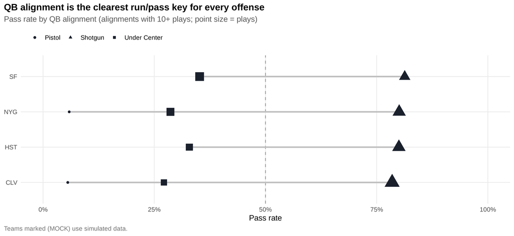

## Headline findings by team

### New York Giants (real data)

- **Tendency:** Passes on 58% of all plays and 51% of neutral early-down plays (1st/2nd down, outside 2-minute drills).
- **Tendency:** QB alignment is a strong run/pass key: under center they run 71% of the time (n=192); in shotgun they pass 80% (n=306).
- **Tendency:** Pistol is a real part of the menu: 17 plays, 6% pass.
- **Strength:** Most efficient run gap: Left End, +0.10 EPA/carry, 5.1 YPC, 56% success (n=27).
- **Strength:** Primary target: M. Nabers (#1) (WR), 30% target share, 53 catches for 648 yards, +0.23 EPA/target, 29 first downs.
- **Vulnerability:** Play action: 21% of dropbacks, -0.05 EPA/play vs +0.12 without (n=63 vs 238).
- **Vulnerability:** Least efficient run gap: Right Tackle, -0.56 EPA/carry, stuffed (0 or fewer yards) on 31% (n=16).

Full report: `NYG/NYG_scouting_report.html` (and .pdf)

### Cleveland Browns (real data)

- **Tendency:** Passes on 65% of all plays and 56% of neutral early-down plays (1st/2nd down, outside 2-minute drills).
- **Tendency:** QB alignment is a strong run/pass key: under center they run 73% of the time (n=114); in shotgun they pass 78% (n=395).
- **Tendency:** Pistol is a real part of the menu: 18 plays, 6% pass.
- **Strength:** Most efficient run gap: Right End, +0.03 EPA/carry, 5.1 YPC, 39% success (n=18).
- **Strength:** Primary target: D. Boston (#12) (WR), 21% target share, 30 catches for 448 yards, +0.06 EPA/target, 19 first downs.
- **Vulnerability:** Play action: 17% of dropbacks, -0.15 EPA/play vs -0.00 without (n=57 vs 285).
- **Vulnerability:** Least efficient run gap: Left Guard, -0.31 EPA/carry, stuffed (0 or fewer yards) on 33% (n=24).

Full report: `CLV/CLV_scouting_report.html` (and .pdf)

Full report: `HST/HST_scouting_report.html` (and .pdf)

### San Francisco 49ers (real data)

- **Tendency:** Passes on 57% of all plays and 51% of neutral early-down plays (1st/2nd down, outside 2-minute drills).
- **Tendency:** QB alignment is a strong run/pass key: under center they run 65% of the time (n=233); in shotgun they pass 81% (n=214).
- **Tendency:** Tell: Shotgun + 3rd Down -> pass 90% of the time (n=61, 95% lower bound 80%).
- **Strength:** Most efficient run gap: Left Tackle, +0.11 EPA/carry, 4.5 YPC, 59% success (n=17).
- **Strength:** Primary target: G. Kittle (#85) (TE), 23% target share, 37 catches for 457 yards, +0.25 EPA/target, 21 first downs.
- **Vulnerability:** Play action: 23% of dropbacks, +0.08 EPA/play vs +0.37 without (n=58 vs 198).
- **Vulnerability:** Least efficient run gap: Right Guard, -0.08 EPA/carry, stuffed (0 or fewer yards) on 7% (n=27).

Full report: `SF/SF_scouting_report.html` (and .pdf)

## How the pipeline works

1. **Load and validate** any `.xlsx` (sheet `GamePBP`) or `.csv` in the PFF GamePBP layout. Headers are normalized, every column is read as text and converted on purpose, and missing optional columns are reported but don’t stop the run.
2. **Build the sample:** one offense, run/pass plays only, downs 1-4, excluding garbage time and QB kneels/spikes. Each filter step is counted in the report.
3. **Analyze** the six scouting questions from the prompt (personnel, down and distance, QB alignment, run concepts, third down and targets, player production) plus passing context and pre-snap tells.
4. **Write findings** with fixed rules (tendencies, strengths, vulnerabilities), each with its sample size, then render the HTML and PDF reports, the CSV/Excel tables and the PNG charts.
5. **Stress tested** on the mock files plus edge-case and regression checks (CSV input, messy headers, multi-team files, missing columns, one game, pass-only and run-only offenses, junk values, config switches).